# Project Analysis

# Analysis of Sentiment using Frequentist and Bayesian Linear regression

```r
library(lmtest); library(corrplot);
library(BayesFactor); library(performance);
library(MCMCpack); library(bayestestR);
library(easystats)
```

Positive correlation → higher value → more positive sentiment

Negative correlation → higher value → more negative sentiment

Magnitude: 0.00–0.10 = very weak, 0.10–0.30 = weak, 0.30+ = moderate+

```r
names(model_data)
```

```
 [1] "user_name"             "user_location"         "user_description"      "user_followers"        "user_friends"
 [6] "user_favourites"       "user_verified"         "text"                  "hashtags"              "source"
[11] "follower_friend_ratio" "text_length"           "word_count"            "hashtag_count"         "has_url"
[16] "has_mention"           "exclamation_count"     "question_count"        "sentiment_compound"    "sentiment_category"
[21] "log_followers"         "log_friends"
```

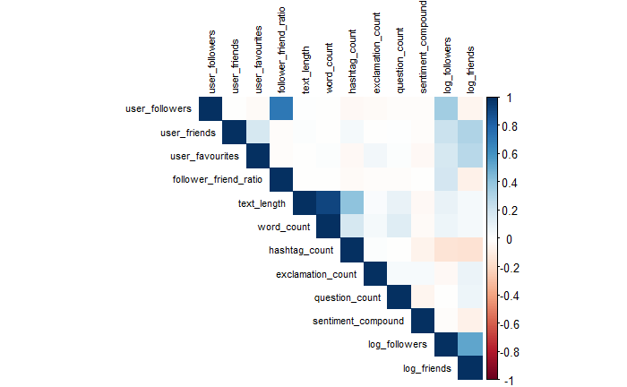

```r
#important to have numeric coulmns for corr
numeric_vars <- model_data %>% select_if(is.numeric)
cor_matrix <- cor(numeric_vars, use = "complete.obs")
corrplot(cor_matrix, method = "color", type = "upper", tl.cex = 0.7, tl.col = "black")
```

```r
cor_matrix[,"sentiment_compound"]
```

```
       user_followers          user_friends       user_favourites follower_friend_ratio           text_length
         -0.010256221          -0.017890832          -0.034740979          -0.005573526          -0.033152849
           word_count         hashtag_count     exclamation_count        question_count    sentiment_compound
         -0.022667772          -0.065804196           0.033446001          -0.059725929           1.000000000
        log_followers           log_friends
         -0.013431174          -0.077257591
```

# FREQUENTIST LINEAR REGRESSION ANALYSIS

Null hyp : No relationship between any predictor and sentiment Alt hyp: At least one predictor significantly affects sentiment

```r
model_formula <- sentiment_compound ~ text_length + word_count + hashtag_count +has_url +
                has_mention + exclamation_count + question_count + log_followers + log_friends +
                follower_friend_ratio

freq_model <- lm(model_formula, data = model_data)
summary(freq_model)
```

```
Call:
lm(formula = model_formula, data = model_data)

Residuals:
     Min       1Q   Median       3Q      Max
-2.00653 -0.08553 -0.00266  0.09638  1.70105

Coefficients:
                        Estimate Std. Error t value Pr(>|t|)
(Intercept)            1.034e-01  1.495e-03  69.150  < 2e-16 ***
text_length            8.212e-05  1.907e-05   4.306 1.66e-05 ***
word_count            -5.314e-04  1.163e-04  -4.570 4.87e-06 ***
hashtag_count         -5.791e-03  1.855e-04 -31.228  < 2e-16 ***
has_urlTRUE            4.865e-03  1.018e-03   4.780 1.75e-06 ***
has_mentionTRUE        8.038e-03  8.594e-04   9.354  < 2e-16 ***
exclamation_count      1.221e-02  5.088e-04  24.007  < 2e-16 ***
question_count        -1.896e-02  7.327e-04 -25.881  < 2e-16 ***
log_followers          6.431e-03  4.311e-04  14.920  < 2e-16 ***
log_friends           -2.295e-02  4.762e-04 -48.183  < 2e-16 ***
follower_friend_ratio -9.652e-08  8.574e-09 -11.257  < 2e-16 ***
---
Signif. codes:  0 ‘***’ 0.001 ‘**’ 0.01 ‘*’ 0.05 ‘.’ 0.1 ‘ ’ 1

Residual standard error: 0.1844 on 259947 degrees of freedom
Multiple R-squared:  0.01886,   Adjusted R-squared:  0.01882
F-statistic: 499.7 on 10 and 259947 DF,  p-value: < 2.2e-16
```

follower_friend_ratio(B approx. 0, p<0.05):statistically significant due to large N, but practically meaningless effect.

We reject the null hypothesis statistically, the model detects multiple predictors affecting sentiment.

```r
check_collinearity(freq_model)# VIF and multicollinearity
```

```
# Check for Multicollinearity

Low Correlation

                  Term  VIF     VIF 95% CI adj. VIF Tolerance Tolerance 95% CI
         hashtag_count 2.05 [ 2.04,  2.06]     1.43      0.49     [0.48, 0.49]
               has_url 1.47 [ 1.46,  1.47]     1.21      0.68     [0.68, 0.69]
           has_mention 1.15 [ 1.14,  1.15]     1.07      0.87     [0.87, 0.88]
     exclamation_count 1.02 [ 1.02,  1.02]     1.01      0.98     [0.98, 0.98]
        question_count 1.04 [ 1.03,  1.04]     1.02      0.97     [0.96, 0.97]
         log_followers 1.58 [ 1.57,  1.59]     1.26      0.63     [0.63, 0.64]
           log_friends 1.61 [ 1.60,  1.62]     1.27      0.62     [0.62, 0.62]
 follower_friend_ratio 1.08 [ 1.07,  1.08]     1.04      0.93     [0.92, 0.93]

High Correlation

        Term   VIF     VIF 95% CI adj. VIF Tolerance Tolerance 95% CI
 text_length 14.14 [14.04, 14.25]     3.76      0.07     [0.07, 0.07]
  word_count 11.93 [11.84, 12.02]     3.45      0.08     [0.08, 0.08]
```

```r
check_residuals(freq_model)#autocorrelation + distribution of residuals
check_outliers(freq_model)
```

[output not shown]

```
OK: No outliers detected.
- Based on the following method and threshold: cook (0.927).
- For variable: (Whole model)
```

Since VIF of all variables are less than 5, we can say them largely independent and do not exhibit harmful multicollinearity, except text_length and word_count with 14.14 and 11.93 respectively, so we can toss them out from analysis.

No Influential Outliers.

# BAYESIAN LINEAR REGRESSION ANALYSIS

```r
model_data <- model_data %>%
  mutate(
    has_url = as.factor(has_url),
    has_mention = as.factor(has_mention)
  ) %>% filter(if_all(where(is.numeric), is.finite))
bf_model <- lmBF(model_formula, data = model_data)
```

```
|----|----|----|----|----|----|----|----|----|----|
```

```r
summary(bf_model)
```

```
Bayes factor analysis
--------------
[1] text_length + word_count + hashtag_count + has_url + has_mention + exclamation_count + question_count + log_followers + log_friends +     follower_friend_ratio : 8.906276e+1053 ±1.29%

Against denominator:
  Intercept only
---
Bayes factor type: BFlinearModel, JZS
```

The Bayes factor for the full model is 8.906276e+1053, which is huge, indicating overwhelming evidence in favor of the model with these predictor(text_length + word_count + hashtag_count + has_url + has_mention + exclamation_count + question_count + log_followers + log_friends + follower_friend_ratio) i.e. in favor of alt hypothesis.

```r
lmout_mcmc= lmBF(sentiment_compound ~ word_count + hashtag_count + has_url + has_mention +
            exclamation_count + question_count + log_followers + log_friends +
            follower_friend_ratio, data = model_data, posterior = TRUE, iterations = 10000)
```

```
|----|----|----|----|----|----|----|----|----|----|
```

```r
summary(lmout_mcmc)
```

```
Iterations = 1:10000
Thinning interval = 1
Number of chains = 1
Sample size per chain = 10000

1. Empirical mean and standard deviation for each variable,
   plus standard error of the mean:

                                                  Mean        SD  Naive SE Time-series SE
mu                                           5.205e-02 4.643e-04 4.643e-06      4.643e-06
word_count-word_count                       -5.386e-05 3.489e-05 3.489e-07      3.662e-07
hashtag_count-hashtag_count                 -5.238e-03 1.339e-04 1.339e-06      1.339e-06
has_url-FALSE                               -3.380e-03 4.573e-04 4.573e-06      4.573e-06
has_url-TRUE                                 3.380e-03 4.573e-04 4.573e-06      4.573e-06
has_mention-FALSE                           -4.556e-03 4.162e-04 4.162e-06      4.165e-06
has_mention-TRUE                             4.556e-03 4.162e-04 4.162e-06      4.165e-06
exclamation_count-exclamation_count          1.216e-02 5.033e-04 5.033e-06      5.033e-06
question_count-question_count               -1.905e-02 7.375e-04 7.375e-06      7.375e-06
log_followers-log_followers                  6.592e-03 4.342e-04 4.342e-06      4.342e-06
log_friends-log_friends                     -2.312e-02 4.775e-04 4.775e-06      4.775e-06
follower_friend_ratio-follower_friend_ratio -9.676e-08 8.611e-09 8.611e-11      0.000e+00
sig2                                         3.400e-02 9.293e-05 9.293e-07      9.293e-07
g_has_url                                    1.204e+00 2.239e+01 2.239e-01      2.239e-01
g_has_mention                                9.596e-01 7.308e+00 7.308e-02      7.308e-02
g_continuous                                 2.412e-02 1.667e-02 1.667e-04      1.690e-04

2. Quantiles for each variable:

                                                  2.5%        25%        50%        75%      97.5%
mu                                           5.114e-02  5.173e-02  5.205e-02  5.236e-02  5.296e-02
word_count-word_count                       -1.214e-04 -7.786e-05 -5.342e-05 -3.030e-05  1.563e-05
hashtag_count-hashtag_count                 -5.501e-03 -5.330e-03 -5.237e-03 -5.149e-03 -4.978e-03
has_url-FALSE                               -4.266e-03 -3.694e-03 -3.377e-03 -3.065e-03 -2.488e-03
has_url-TRUE                                 2.488e-03  3.065e-03  3.377e-03  3.694e-03  4.266e-03
has_mention-FALSE                           -5.364e-03 -4.839e-03 -4.557e-03 -4.277e-03 -3.741e-03
has_mention-TRUE                             3.741e-03  4.277e-03  4.557e-03  4.839e-03  5.364e-03
exclamation_count-exclamation_count          1.118e-02  1.182e-02  1.217e-02  1.250e-02  1.315e-02
question_count-question_count               -2.051e-02 -1.955e-02 -1.906e-02 -1.856e-02 -1.760e-02
log_followers-log_followers                  5.733e-03  6.302e-03  6.595e-03  6.885e-03  7.455e-03
log_friends-log_friends                     -2.405e-02 -2.343e-02 -2.312e-02 -2.280e-02 -2.219e-02
follower_friend_ratio-follower_friend_ratio -1.133e-07 -1.025e-07 -9.684e-08 -9.100e-08 -7.970e-08
sig2                                         3.382e-02  3.394e-02  3.400e-02  3.406e-02  3.418e-02
g_has_url                                    3.451e-02  8.978e-02  1.770e-01  4.331e-01  5.004e+00
g_has_mention                                3.328e-02  8.933e-02  1.815e-01  4.324e-01  4.555e+00
g_continuous                                 8.315e-03  1.433e-02  1.985e-02  2.843e-02  6.469e-02
```